# Tools for spatio-temporal data in R

Michael Sumner  
14 March 2014

Southern Ocean Ecosystem Change Program, AAD michael.sumner@aad.gov.au

[figure not shown]

### Summary

- Tools in R for spatio-temporal data
- Extending R tools for AAD data
- Extensible extraction functions
- Map projections, frequently hidden
- Prospects - open development, web delivery with Shiny

### The data repository

- sea ice concentration
- chlorophyll-a
- sst
- wind vectors
- current vectors
- ssh/ssha
- model outputs [lon, lat, [depth], time]
- bathymetry

Extracting data for polygonal regions, boundaries, transects, point samples etc

Tool development captured in R packages

### R Tools

R and extension packages provide a wide variety of spatial tools

- Raster and vector, read/write: gdal, ncdf, 'native'
- Formal classes, metadata-rich objects
- Map projections and transformations
- Geometry manipulation, union, intersection, buffers

See the Spatial 'Task View' http://cran.csiro.au/web/views/Spatial.html

### Raster tools for 2D and 3D grids

Low level

- cellFromXY(x, pts)
- xyFromCell(x, cellnum)
- getValues(x, row)
- getValues(x, format = “matrix”)
- adjacent(x, 10)
- writeRaster(x, filename, …)

High level

- extent(x); dim(x); projection(x)
- merge, crop, projectRaster, aggregate, reclass, resample, rasterize, distance, focal, plotRGB, terrain …
- Raster algebra: x + y; sqrt(y); log(x) etc.
- Temporal or 'Z' axis for 3D

Regridding and extraction

### Example: Etopo2 and aggregated depth values

- Read grid data and crop
- Extract aggregate grid values under polygon objects
- Reproject grid to polygons (for plotting)

```r
library(raster)
bb <- extent(25, 90, -70, -40)
topo <- crop(raster("Etopo2.tif"), bb)
topo[topo > -1] <- NA
```

```r
polys <- readOGR(".", "SSRUs")
polys$meantopo <- extract(topo, polys, fun = mean, na.rm = TRUE)
```

```r
## reproject the raster and plot both layers
projtopo <- projectRaster(topo, crs = projection(polys))
plot(projtopo)
incl <- !is.na(polys$meantopo)
plot(polys[incl,], add = TRUE, col = "#333333333B3")
text(coordinates(polys)[incl,], lab = format(polys$meantopo[incl], digits = 5), cex = 0.7)
```

### Example: Etopo2 and aggregated depth values

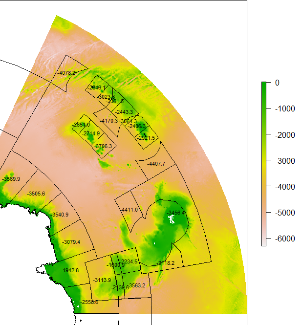

### R tools - time series grid

High-level work flow also applies to time series grid data

```r
library(raster)
bb <- extent(100, 160, -70, -50)

## will leave bulk data on disk, read on demand as required
sst <- crop(brick("sst.wkmean.1990-present.nc"), bb, filename = "ReynoldsSST_subset.nc")

polys <- readOGR(".", "PolygonShapefile")

## matrix of [polyID,weeks]
(sstmatrix <- extract(sst, polys, fun = mean))
```

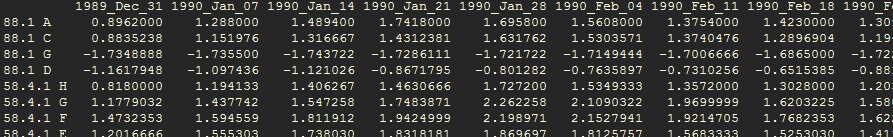

### R Tools - time-series data

Raster can read from a variety of file types, and deal with 3D space-time grids, or assemble them from individual files

```r
library(raster)
dp <- "//aad.gov.au/files/AADC/Scientific_Data/Data/gridded/data"
sp <- "seaice/ssmi/ifremer/antarctic/daily/2013"
files <- c("20130719.nc", "20130726.nc", "20130802.nc", "20130809.nc", "20130816.nc", "20130823.nc", "20130830.nc", "20130906.nc")

fs <- file.path(dp, sp, files)

icedata <- stack(fs)
```

R AAD tools adds simplified helpers for rogue file collections:

```r
library(raadtools)
dates <- seq(as.Date("2013-07-19"), by = "1 week", length = 8)
icedata <- readice(dates, product = "ssmi")
```

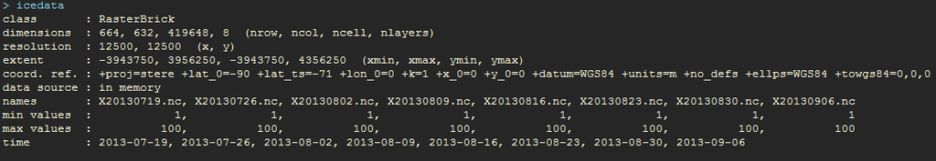

### R AAD Tools - extensions to existing tools

```r
(icedata <- readice(dates, product = "smmi"))
```

The raadtools package provides

- catalogue of available files in the repository
- normalization of input dates (unique, sort) match to repository dates
- read[x] function for product [x] with consistent structure
- record/fix incomplete/missing metadata, orientation, etc.
- flexible extraction methods, read slabs or extract point values

### R Tools - data extraction

Reading slabs is not necessarily what we want.

```r
## read myPoints data
myPoints <- read.table("fArchive.csv", sep = ",")
myPoints$datetime <- as.POSIXct(myPoints$datetime)
dcut <- cut(myPoints$datetime, by = "1 day")
levs <- levels(dcut)

## read[x] will normalize input dates
allice <- readice(myPoints$datetime)
for (i in seq_along(levs)) {
    ## match to today's ice
    ## ...
}
```

We probably can't load the entire time series first, and we probably shouldn't …

### R Tools - data extraction

Obviously it's smarter to only read today's slab:

```r
myPoints$ice <- as.numeric(NA)
for (i in seq_along(levs)) {
  ## match this day's myPoints data to the ice
  isub <- myPoints[levs == levs[i], c("long", "lat")]

  ice <- readice(isub$datetime[1L])
  vals <- extract(ice, isub, method = "bilinear")
  myPoints$ice[levs == levs[i]] <- vals
}
```

This is getting there but

- cannot extract at longlat because the grid is in Polar Stereographic
- need extra handling to interpolate in time
- perhaps aggregate the grid to a lower resolution
- code required starts to get complicated
- and we need to write this for each data type …

### R Tools - extract methods

The raster construct for extracting data from grids:

```r
library(raster)
r <- raster("myMegaSplat.grd")
extract(r, [query])
```

Where, [query] is:

- a data.frame/matrix of coordinates (must match projection of raster)
- SpatialPoints*, SpatialLines*, SpatialPolygons* (reprojection will be performed if required)

It provides options for extraction, and we can aggregate into geometries

```r
extract(x, query, fun = mean)

extract(x, query, fun = function(x) dowhatever(x))
```

- if raster is 2D, we get value/s for each point/line/polygon
- if raster is 3D, we get a *matrix* of values for each point/line/polygon at each time step

### R AAD Tools - read functions for various data products

The raadtools package applies extract() to functions, with query a table of longitude, latitude, date-time:

```r
xyt <- c("long", "lat", "datetime")
## extract
myPoints$iceconcentration <- extract(readice, myPoints[,xyt])
```

Geek alert: raadtools adds *methods* for the S4 *generic* raster::extract()

We can do the same with other read functions, and provide options:

```r
myPoints$uCurr <- extract(readcurr, myPoints[,xyt], uonly = TRUE)
myPoints$vCurr <- extract(readcurr, myPoints[,xyt], vonly = TRUE)

myPoints$interpsst <- extract(readsst, myPoints[,xyt], ctstime = TRUE, method = "bilinear")

myPoints$regridSSHA <- extract(readssh, myPoints[,xyt], fact = 8, ssha = TRUE)
```

This is *extensible*: by adding new functions we can use those, without rebuilding/reinstalling the package providing the extract method.

Similar extraction methods are possible for other scenarios.

### R AAD Tools - read / extract

If *readwhatever()* knows the grid, projection, time axis, catalogue, *extract* just applies the same engine to that.

- readchla: weekly/monthly, SeaWIFS/MODIS, oceancolor/Robert Johnson
- readcurrents: weekly AVISO surface currents
- readfastice: East Antarctic Fast Ice Coverage, 2000-2008
- readice: daily/monthly, NSIDC/SSMI, southern hemisphere
- readfronts: weekly Sokolov/Rintoul frontal regions
- readmld: montly climatology Sallee mixed layer depth, Southern Ocean
- readrapid_response: daily RGB MODIS image, southern hemisphere
- readssh: weekly Sea Surface height/anomaly, global
- readsst: daily/monthly SST, global
- readwind: weekly surface wind vectors, global
- readtopo: Gebco 2008, IBCSO, Etopo1/2, Kerguelen, George V Terre Adelie, Smith and Sandwell

### A Map projection

- … is a systematic transformation of the latitudes and longitudes of locations on the surface of a sphere or an ellipsoid into locations on a plane.
- **All map projections distort** the surface in some fashion.
- **Depending on the purpose** of the map, **some distortions are acceptable and others are not**; therefore different map projections exist in order to preserve some properties of the sphere-like body **at the expense of other properties**.
- **There is no limit to the number of possible map projections**

http://en.wikipedia.org/wiki/Map_projection

### R AAD Tools - data and projections

NSIDC data in native form, matrix [332,316], map units in kilometres:

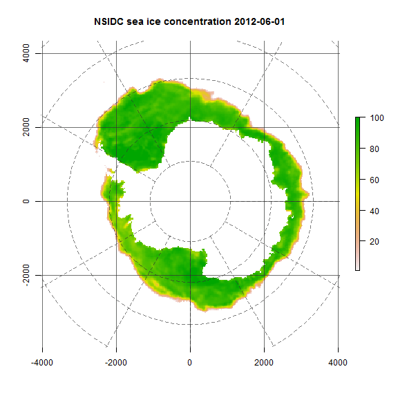

solid line is km-grid, dash line is graticule

### NSIDC ice - a Polar projection

This is a (south Polar) Stereographic projection on the WGS84 datum, with

- central longitude 0.0
- central latitude -90.0
- true-scale latitude -71.0
- units of kilometres
- (false easting/northing both 0.0, hence [0,0] is middle of the page, at south pole)
- **conformal,** i.e. good for **preserving the *shape* of objects locally** (though *not* for calculating area over large regions …)

PROJ.4

+proj=stere +lat_0=-90 +lat_ts=-71 +lon_0=0 +k=1 +x_0=0 +y_0=0 +datum=WGS84 +units=km +no_defs +ellps=WGS84 +towgs84=0,0,0"

Metadata allows treating this layer like a GIS would, for display, manipulation, extraction of data and conversion to other forms.

### Data and map projections

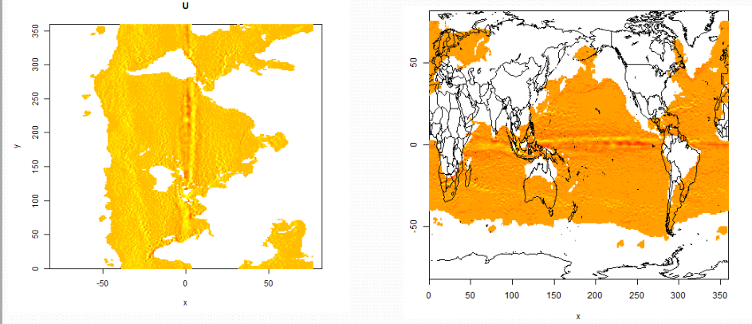

This is what some GIS packages see from AVISO ocean currents stored in NetCDF.

Reorient the grid, looks right, but map doesn't line up …

### Mercator-grid, longlat vs native

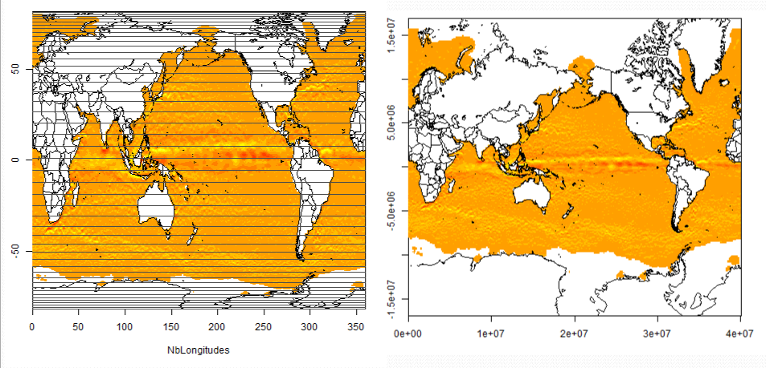

PROJ.4 +proj=merc +lon_0=0 +k=1 +x_0=0 +y_0=0 +ellps=WGS84 +over +units=m +no_defs

- Left panel is *rectilinear*, latitude lines are denser towards the poles.
- Right panel is *regular in native projection*, and this allows straightforward usage (and fast extraction methods).

### Which projection?

A global projection with acceptable compromises for all purposes is impossible. Area, shape, distance and angle cannot be all balanced at once.

Projections for smaller areas provide much easier choices with less drastic compromise, e.g. polar regions

- There is no easy or right answer, but disguising these compromises rarely helps
- Longitude and latitude arrays add unnecessary complexity and complication

Work with the coordinate system as delivered, transform queries to/from the native projection

### Other map projections in common use

**Spherical Mercator** Smith/Sandwell topography-bathymetry +proj=merc +lon_0=0 +k=1 +x_0=0 +y_0=0 +a=6370997 +b=6370997 +units=m +no_defs

**WGS84 Mercator** AVISO currents, SSH/SSHA, Sokolov/Rintoul front zones +proj=merc +lon_0=0 +k=1 +x_0=0 +y_0=0 +ellps=WGS84 +units=m +no_defs

**Equal Area Cylindrical** Fraser / Massom fast ice +proj=cea +lon_0=91 +lat_0=-90 +lat_ts=-65 +datum=WGS84 +ellps=WGS84 +towgs84=0,0,0  
+proj=cea +ellps=WGS84

**Lambert Azimuthal Equal Area** CCAMLR management zone shapefiles +proj=laea +lat_0=-90 +lon_0=0 +x_0=0 +y_0=0 +datum=WGS84 +units=m +no_defs +ellps=WGS84 +towgs84=0,0,0

**(North Polar) Stereographic** NSIDC, SSMI products, North-Hemi Snow Cover Extent +proj=stere +lat_0=90 +lat_ts=70 +lon_0=-45 +k=1 +x_0=0 +y_0=0 +a=6378273 +b=6356889.449 +units=m +no_defs  
+proj=stere +lat_0=90 +lon_0=10 +ellps=WGS84

**(South Polar) Stereographic on the sphere** Arrigo/Dijken primary production +proj=stere +lat_0=-90 +lon_0=180 +ellps=sphere

**Longitude / latitude on WGS84** (no kidding!) +proj=longlat +ellps=WGS84 +datum=WGS84 +no_defs +towgs84=0,0,0

### Conformal?

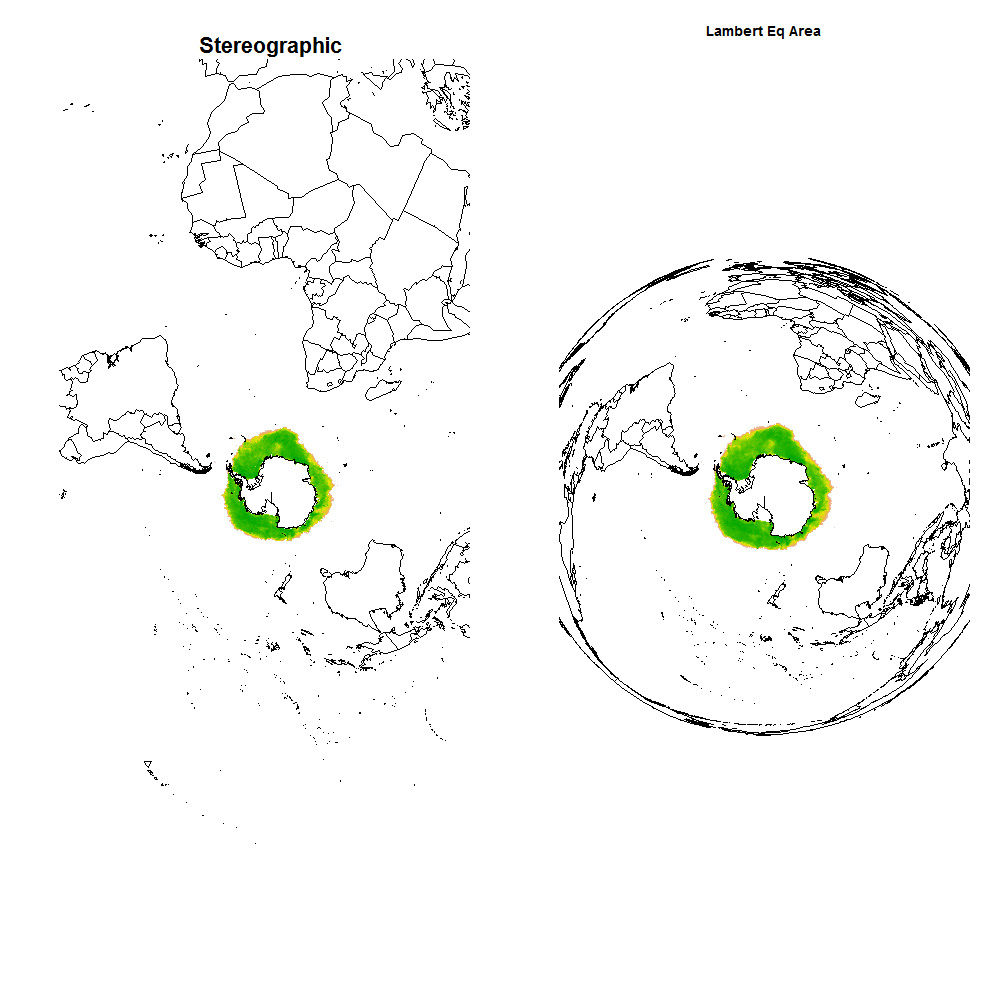

### R code

```r
library(raadtools)
library(rgdal)
library(maptools)
data(wrld_simpl)
## prepare base data, transform copies to LAEA for comparison
xst <- readice()
library(rgdal);library(maptools);data(wrld_simpl)
wst <- spTransform(wrld_simpl, CRS(projection(xst)))
xla <- projectRaster(xst, crs = gsub("stere", "laea", projection(xst)))
wla <- spTransform(wrld_simpl, CRS(projection(xla)))
## extents for both
est <- extent(xst) + 1.2e7
lst <- extent(xla) + 1.2e7

## plot
par(mfcol = c(1, 2), cex = 1.5)
plot(est, col = "white", axes = FALSE, xlab = "", ylab = "", asp = 1, main = "Stereographic")
plot(xst, add = TRUE, legend = FALSE)
plot(wst, add = TRUE)
plot(lst, col = "white", axes = FALSE, xlab = "", ylab = "", asp = 1, main = "Lambert Eq Area");
plot(xla, add = TRUE, legend = FALSE)
plot(wla, add = TRUE)
```

### Other code

Work with the coordinate system as delivered, transform to/from the native projection

Not this! (Note, this approach looks the same in any language).

```r
##' load data arrays from binary files
nn = 209091
fid = open('data.bin','rb')
x=readBin(fid,"integer",n=nn,size=1)
close(fid)
##' load lons/lats
fid = open('lats','rb')
lat=readBin(fid,"integer",n=nn,size=4)/1e5
close(fid)
fid = open('lons','rb')
lon=readBin(fid,"integer",n=nn,size=4)/1e5
close(fid)

##' area-cell or point-cell?
##' ?? ...
```

### Open development

- RStudio server
- users log-in via web browser
- interface identical to RStudio, shared R installation, shared network, etc.
- streamlining tools to update/synchronize the file collections

[figure not shown]

### Open development

[figure not shown]

### Deploying to the web with Shiny

Shiny lets us write very simple R code, with a little bit of wrapping and spin it up in a browser:

```r
list.files("shinyrun")
##[1] "server.R" "ui.R"
## server.R
library(shiny)
library(raadtools)
strf <- "NSIDC_%d_%b_%Y"
shinyServer(function(input, output) {
  output$rasterPlot <- renderPlot({
   dates <- input$dateRange
   x <- readice(dates)
   names(x) <- format(getZ(x), strf)
   plot(x)
  })})
## ui.R
library(shiny)
fs <- icefiles()
mindate <- as.Date(min(fs$date))
maxdate <- as.Date(max(fs$date))
shinyUI(pageWithSidebar(
  headerPanel("NSIDC daily sea ice"),
  sidebarPanel(dateRangeInput("dateRange", "Dates:",
      start = mindate, end = maxdate,
      min = mindate, max = maxdate, separator = "and")
  ),
    mainPanel(plotOutput("rasterPlot"))))
```

### Deploy on a server

(such as “localhost”)

```r
## load the shiny package and point to a simple app
library(shiny)

dp <- "//aad.gov.au/files/Transfer"

runApp(file.path(dp, "shinyrun"))
```

### Extract data for points with Shiny app

```r
library(shiny)
runApp("shinyExtract")
```

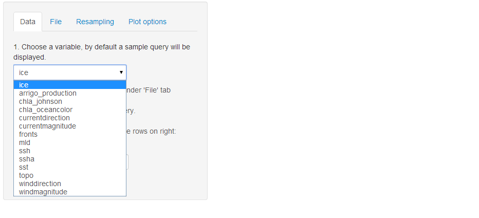

### Extract data for points with Shiny app

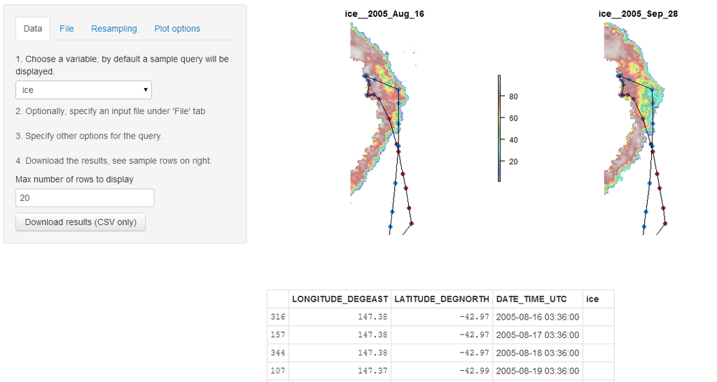

### Extract data for points with Shiny app

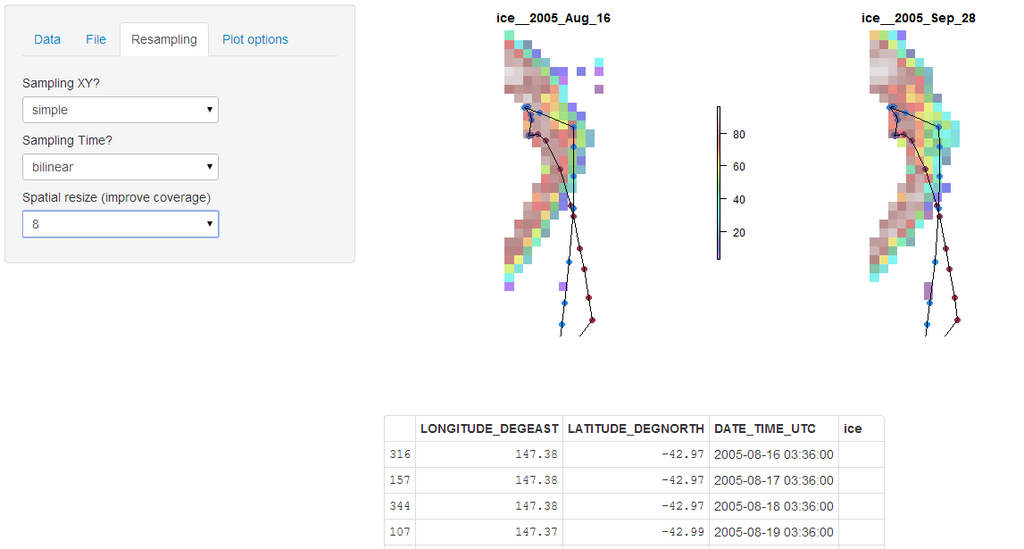

### What next?

- extend extract(function, query) for polygons/lines with time-range / time-spacing
- file catalogue is clunky, need tools (Ben Raymond has the solution)
- relation to other data portals?
- extend extract model to trip/track objects, tools for merging with track-estimates
- host the tools on fast, accessible hardware

Many thanks to long-suffering colleagues for conversations and testing.

Interested users, testers, developers, collaborators? michael.sumner@aad.gov.au

http://www.soki.aq/x/eolw

[figure not shown]

### Structure of read functions (1)

```r
##' Read Polar model data.
##'
##' Polar biology model, on Stereographic grid.
##' @title Polar data
##' @param date date or dates of data to read
##' @param returnfiles if TRUE return just the files from \code{polarfiles}
##' @param time.resolution choice of temporal resolution, weekly only
##' @param xylim crop or not
##' @param ... ignored
##' @return RasterLayer or RasterBrick
##' @export
readpolar <- function(date,  time.resolution = "weekly", xylim = NULL, returnfiles = FALSE, ...) {
      ## private function to read a single file/time slice specific to this product
      read0 <- function(x) {
        proj <- "+proj=stere +lat_0=-90 +lon_0=180 +ellps=sphere"
        offset <- c(5946335, 5946335)
        dims <- c(1280L, 1280L)
        pdata <- readBin(x, numeric(), prod(dims), size = 4, endian = "little")
        pdata[pdata < 0] <- NA
        x <- list(x = seq(-offset[1L], offset[1L], length = dims[1L]),
                   y =  seq(-offset[2L], offset[2L], length = dims[2L]),
                   z = matrix(pdata, dims[1L])[rev(seq_len(dims[2L])),])
        raster(x, crs = proj)

    }
    ## process input options
    time.resolution <- match.arg(time.resolution)
    files <- polarfiles()
    if (returnfiles) return(files)

    ## provide a default for readpolar() with no input
    if (missing(date)) date <- min(files$date)
    date <- timedateFrom(date)


   ## continued . . .



    }
```

### Structure of read functions (2)

```r
  ## readpolar <- function(date,  time.resolution = "weekly", xylim = NULL, returnfiles = FALSE, ...) {

  ## cont.

    ## normalize input to file dates
    files <- .processFiles(date, files, time.resolution)

    ## crop if requested
    cropit <- FALSE
    if (!is.null(xylim)) {
        cropit <- TRUE
        cropext <- extent(xylim)
    }

    ## collect individual slices and bundle as a RasterBrick
    nfiles <- nrow(files)
    r <- vector("list", nfiles)
    for (ifile in seq_len(nfiles)) {
        r0 <- read0(files$fullname[ifile])
        if (cropit)
            r0 <- crop(r0, cropext)
        r[[ifile]] <- r0
    }
    r <- brick(stack(r))

    ## tidy up the names and the 3rd axis metadata
    names(r) <- sprintf("polar_%s", format(files$date, "%Y%m%d"))
    setZ(r, files$date)
}
```